# Sesión 03 · Visualización con ggplot2

Notebook de práctica — Introducción a R, semestre 2027-1

Autores/as

Dra. Yalbi Itzel Balderas-Martínez

Ing. Luis Alberto Meza Cova

## Antes de empezar

```r
library(ggplot2)
```

Si esa línea da error, falta instalar el paquete. Corre `install.packages("ggplot2")` **una vez** y vuelve aquí.

Toda la sesión construye **una sola gráfica**: empieza vacía y termina publicable, con una capa más cada vez.

## 1. Los datos: `mpg`

`mpg` viene dentro de `ggplot2`, así que no hay nada que descargar.

```r
str(mpg)
```

```
tibble [234 × 11] (S3: tbl_df/tbl/data.frame)
 $ manufacturer: chr [1:234] "audi" "audi" "audi" "audi" ...
 $ model       : chr [1:234] "a4" "a4" "a4" "a4" ...
 $ displ       : num [1:234] 1.8 1.8 2 2 2.8 2.8 3.1 1.8 1.8 2 ...
 $ year        : int [1:234] 1999 1999 2008 2008 1999 1999 2008 1999 1999 2008 ...
 $ cyl         : int [1:234] 4 4 4 4 6 6 6 4 4 4 ...
 $ trans       : chr [1:234] "auto(l5)" "manual(m5)" "manual(m6)" "auto(av)" ...
 $ drv         : chr [1:234] "f" "f" "f" "f" ...
 $ cty         : int [1:234] 18 21 20 21 16 18 18 18 16 20 ...
 $ hwy         : int [1:234] 29 29 31 30 26 26 27 26 25 28 ...
 $ fl          : chr [1:234] "p" "p" "p" "p" ...
 $ class       : chr [1:234] "compact" "compact" "compact" "compact" ...
```

```r
dim(mpg)
```

```
[1] 234  11
```

```r
head(mpg, n = 4)
```

```
# A tibble: 4 × 11
  manufacturer model displ  year   cyl trans      drv     cty   hwy fl    class
  <chr>        <chr> <dbl> <int> <int> <chr>      <chr> <int> <int> <chr> <chr>
1 audi         a4      1.8  1999     4 auto(l5)   f        18    29 p     compa…
2 audi         a4      1.8  1999     4 manual(m5) f        21    29 p     compa…
3 audi         a4      2    2008     4 manual(m6) f        20    31 p     compa…
4 audi         a4      2    2008     4 auto(av)   f        21    30 p     compa…
```

Las columnas que se usan hoy:

| Columna | Qué es |
| --- | --- |
| `displ` | cilindrada, en litros |
| `hwy` | rendimiento en carretera, millas por galón |
| `cty` | rendimiento en ciudad |
| `drv` | tracción: `4`, `f` (delantera), `r` (trasera) |
| `class` | tipo de vehículo |

```r
table(mpg$drv)
```

```
  4   f   r
103 106  25
```

```r
table(mpg$class)
```

```
   2seater    compact    midsize    minivan     pickup subcompact        suv
         5         47         41         11         33         35         62
```

## 2. La gráfica mínima

Tres piezas: qué tabla, qué variable a qué eje, qué se dibuja.

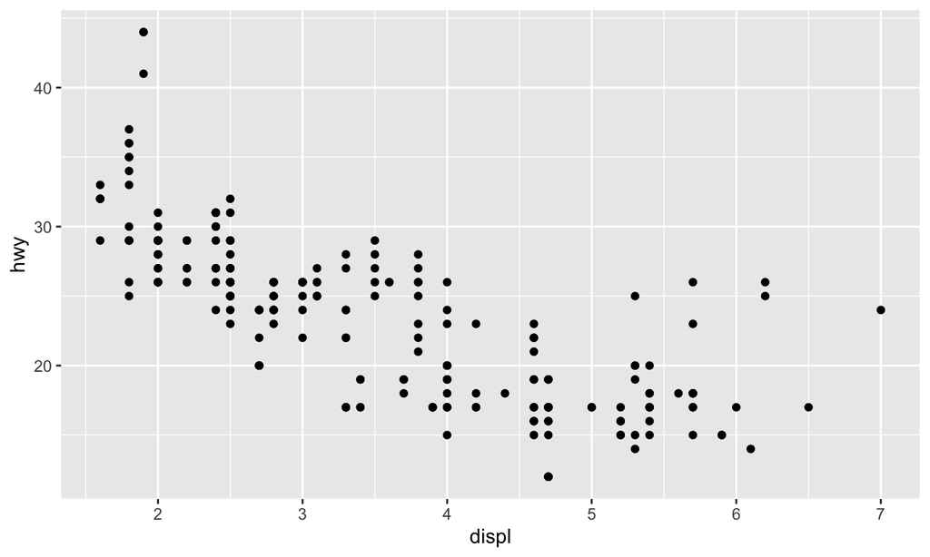

```r
ggplot(data = mpg) +
  geom_point(aes(x = displ, y = hwy))
```

**¿Cómo describirías la relación?** Negativa: a más cilindrada, menos millas por galón.

### El `+` añade capas

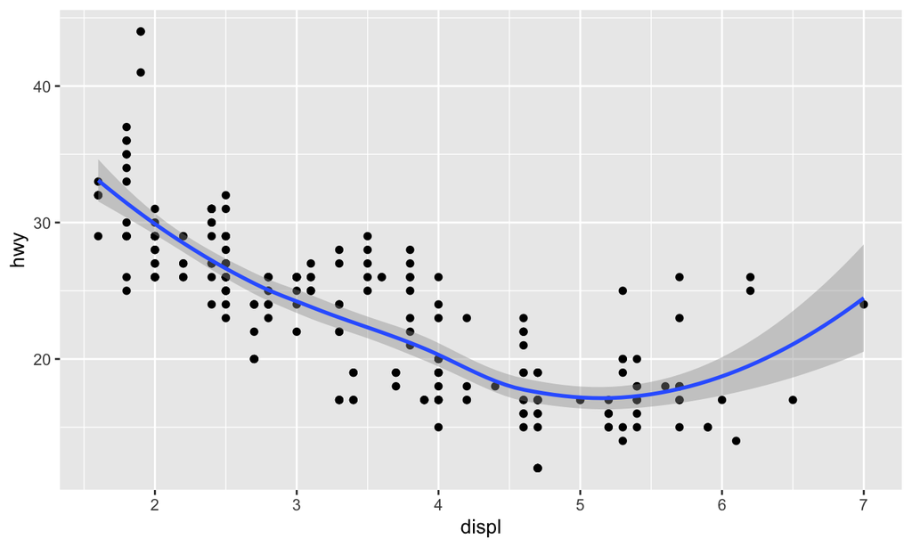

```r
ggplot(data = mpg) +
  geom_point(aes(x = displ, y = hwy)) +
  geom_smooth(aes(x = displ, y = hwy))
```

### El mapeo por defecto

Repetir el `aes()` en cada capa no hace falta:

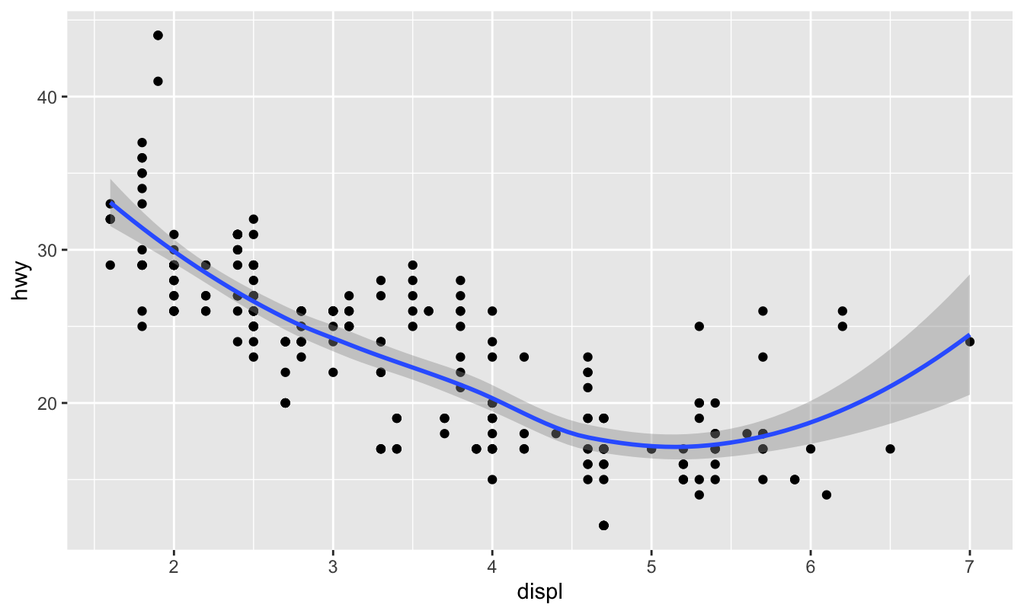

```r
ggplot(data = mpg, aes(x = displ, y = hwy)) +
  geom_point() +
  geom_smooth()
```

Es la forma en que verás casi todo el código de `ggplot2` escrito por otros.

## 3. Mapear no es fijar

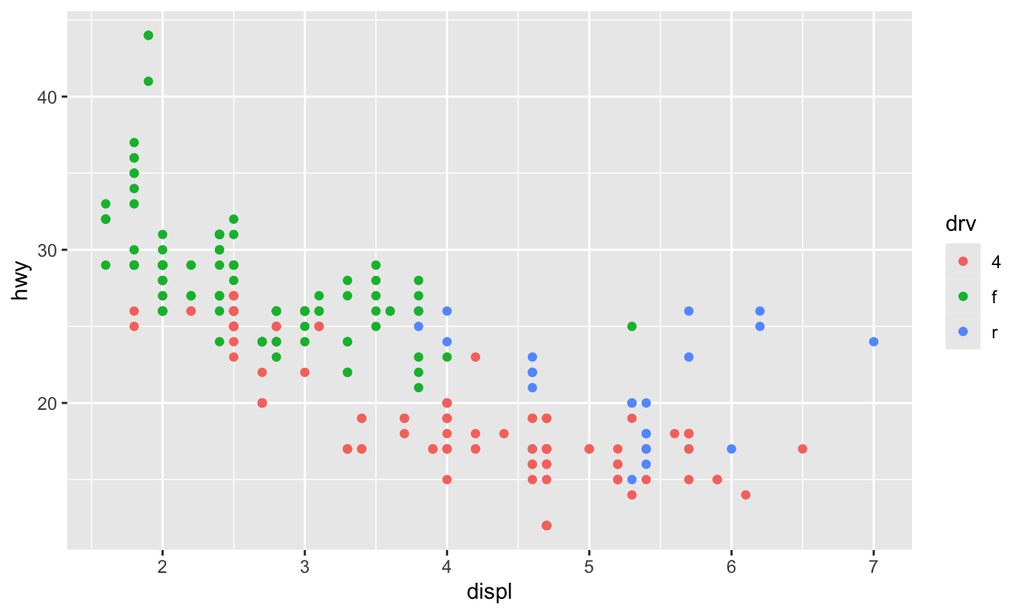

```r
# Mapea: el color DEPENDE de una variable
ggplot(mpg, aes(x = displ, y = hwy, colour = drv)) +
  geom_point()
```

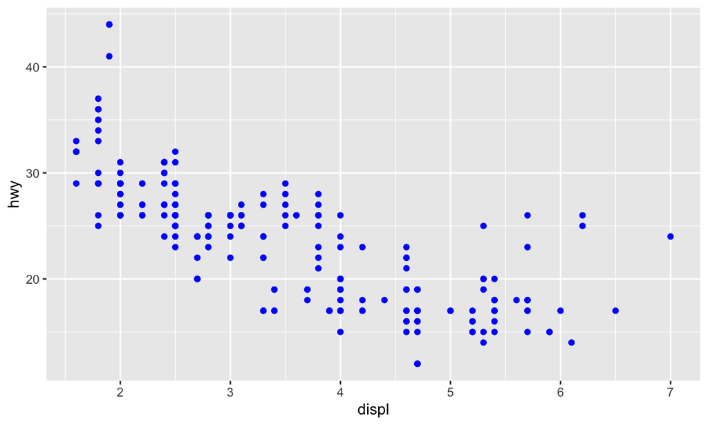

```r
# Fija: el color es azul, sin más
ggplot(mpg, aes(x = displ, y = hwy)) +
  geom_point(colour = "blue")
```

### El error más común de todos

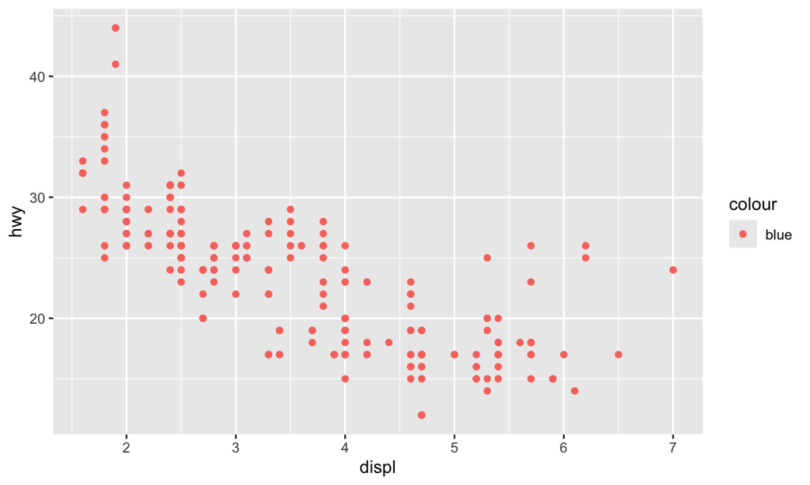

```r
ggplot(mpg, aes(x = displ, y = hwy)) +
  geom_point(aes(colour = "blue"))
```

Mira la leyenda. No pintó de azul: creó una variable con un solo valor —el texto `"blue"`—, la mapeó al color y le puso leyenda.

**Importante**

Dentro de `aes()` van **variables**. Fuera de `aes()` van **valores**.

### Otras estéticas

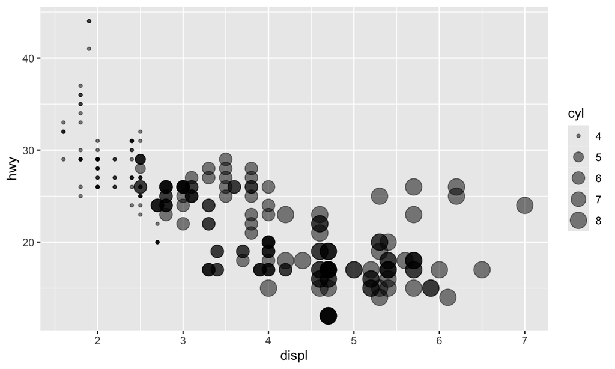

```r
ggplot(mpg, aes(x = displ, y = hwy, size = cyl)) +
  geom_point(alpha = 0.5)
```

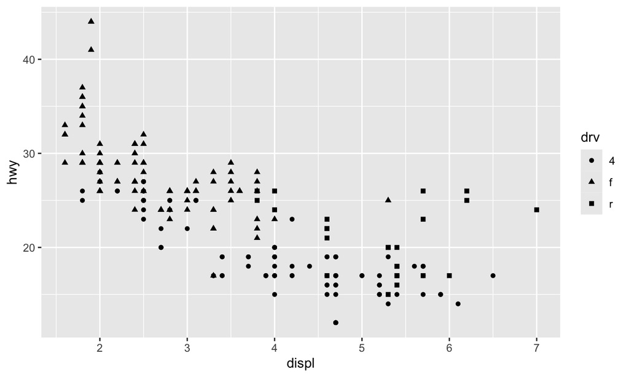

```r
ggplot(mpg, aes(x = displ, y = hwy, shape = drv)) +
  geom_point()
```

`shape` funciona con tres categorías. Prueba a mapearlo a `class`, que tiene siete, y mira la advertencia que da R.

## 4. Geometrías

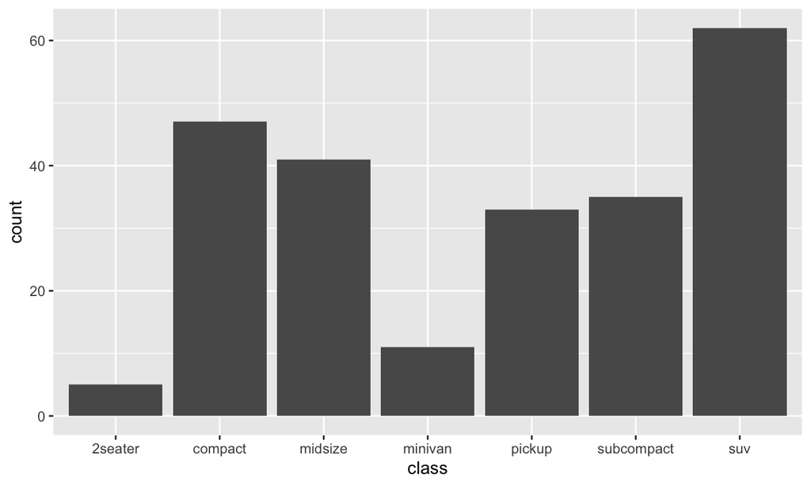

```r
ggplot(mpg, aes(x = class)) +
  geom_bar()
```

`geom_bar()` **cuenta filas**. Si tu tabla ya trae el total, va `geom_col()`:

```r
# El resumen se CALCULA desde los datos, no se escribe a mano: así no puede
# quedar desactualizado ni traer un número inventado.
resumen <- aggregate(hwy ~ drv, data = mpg, FUN = mean)
resumen
```

```
  drv      hwy
1   4 19.17476
2   f 28.16038
3   r 21.00000
```

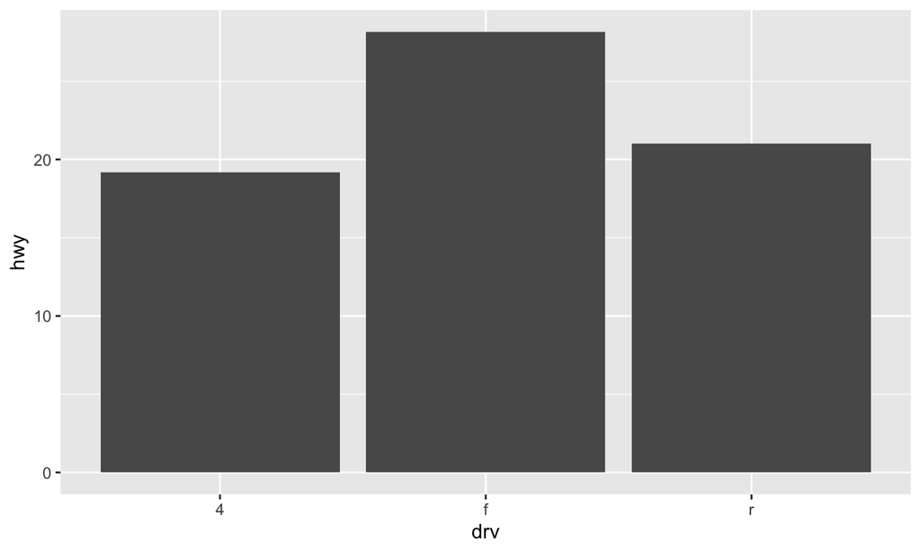

```r
ggplot(resumen, aes(x = drv, y = hwy)) +
  geom_col()
```

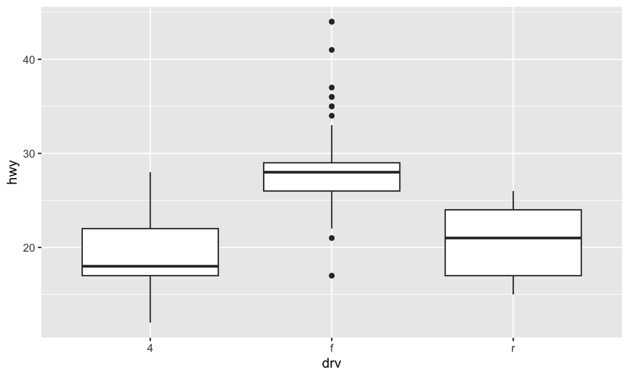

```r
ggplot(mpg, aes(x = drv, y = hwy)) +
  geom_boxplot()
```

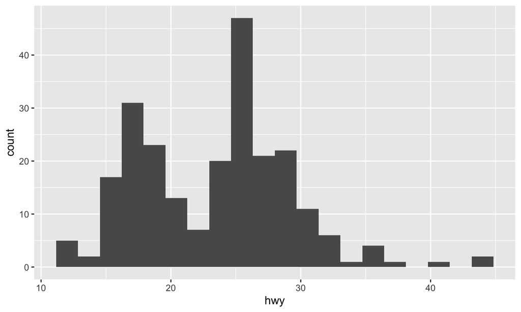

```r
ggplot(mpg, aes(x = hwy)) +
  geom_histogram(bins = 20)
```

**TipEjercicio 1 · tu primera gráfica**

1. Dispersión de `cty` (eje x) contra `hwy` (eje y).
2. Colorea los puntos según `class`.
3. Añade una línea de tendencia.
4. ¿Cómo describirías la relación entre `cty` y `hwy`? ¿Te sorprende?

### Respuesta

```r
ggplot(mpg, aes(x = cty, y = hwy, colour = class)) +
  geom_point() +
  geom_smooth(method = "lm", se = FALSE)
```

La relación es **fuertemente positiva y casi lineal**: las dos variables miden lo mismo —consumo— en condiciones distintas, así que un coche eficiente lo es en ciudad y en carretera.

Que una gráfica confirme lo obvio también es un resultado: sirve para validar que estás leyendo bien los ejes.

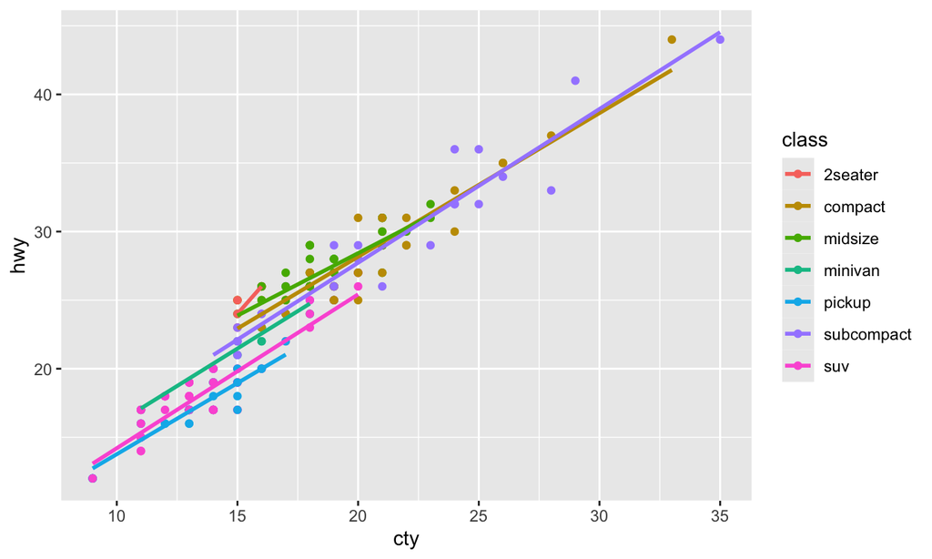

```r
ggplot(mpg, aes(x = cty, y = hwy, colour = class)) +
  geom_point() +
  geom_smooth(method = "lm", se = FALSE)
```

## 5. Facetas

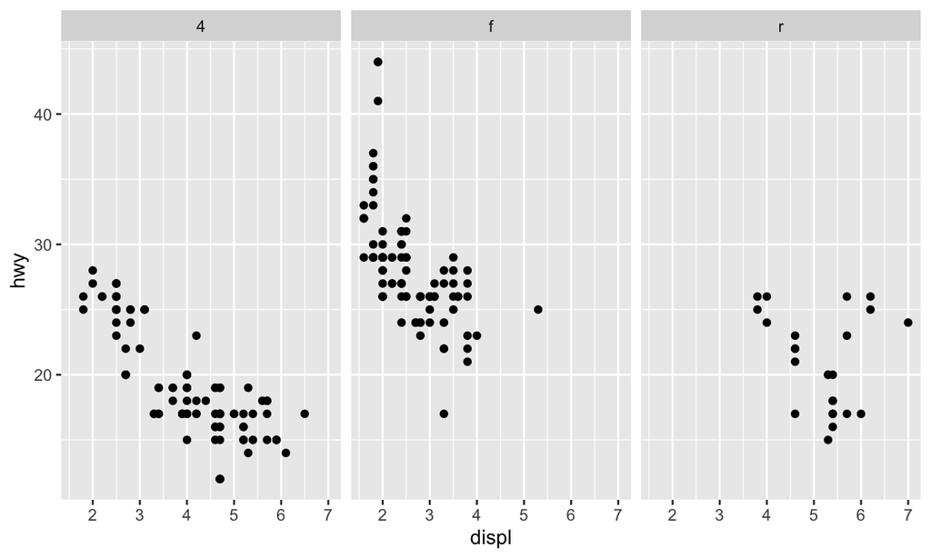

```r
ggplot(mpg, aes(x = displ, y = hwy)) +
  geom_point() +
  facet_wrap(~ drv)
```

Tres paneles, **con los mismos ejes**. Esa es la razón de existir de las facetas: tres gráficas sueltas con ejes distintos engañan.

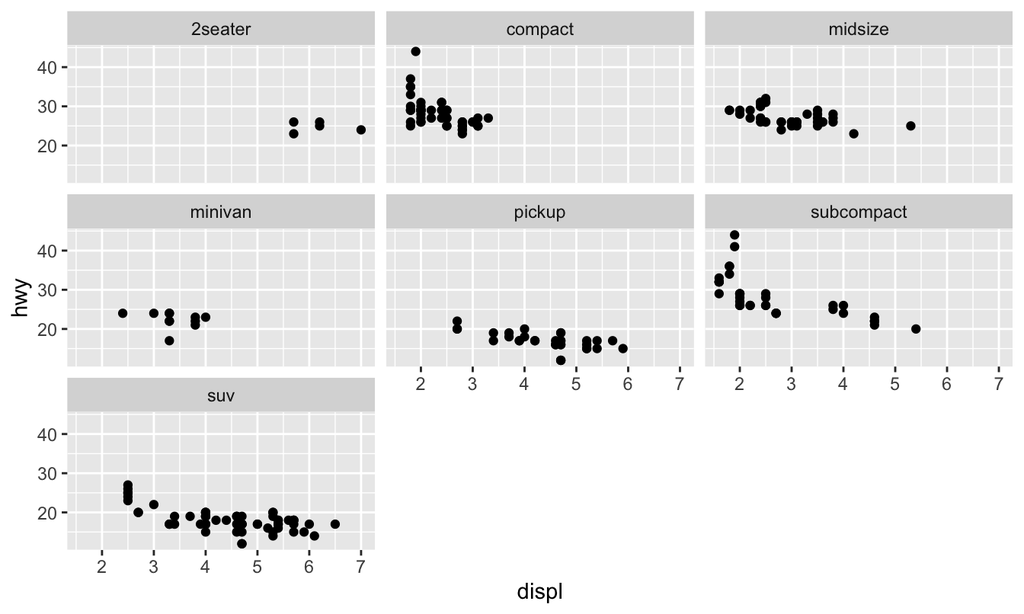

```r
ggplot(mpg, aes(x = displ, y = hwy)) +
  geom_point() +
  facet_wrap(~ class)
```

### `facet_grid`: dos variables

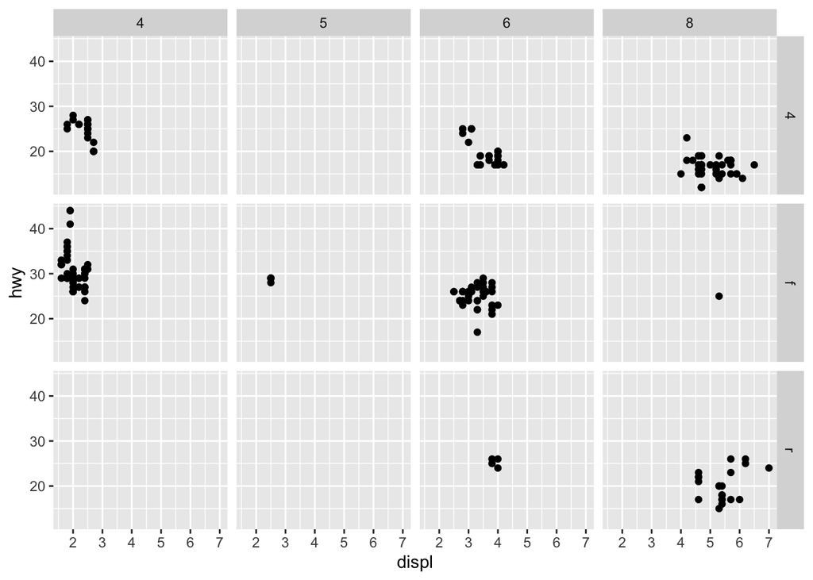

```r
ggplot(mpg, aes(x = displ, y = hwy)) +
  geom_point() +
  facet_grid(drv ~ cyl)
```

Fíjate en los paneles vacíos: **eso también es información**. Esa combinación de tracción y cilindrada no existe en los datos.

**TipEjercicio 2 · color o faceta**

Haz la misma gráfica de `displ` contra `hwy` de dos formas: coloreando por `drv` y facetando por `drv`. ¿Qué pregunta responde mejor cada una?

### Respuesta

Colorear responde **«¿cuál grupo rinde más?»**: los grupos están superpuestos y se comparan de un vistazo.

Facetear responde **«¿la relación tiene la misma forma en los tres?»**: cada grupo se ve sin solapamiento.

No hay una mejor. Hay una que responde tu pregunta.

## 6. Escalas

Siempre hay una escala. Si no la escribes, `ggplot2` pone una por defecto; escribirla es **sustituirla**.

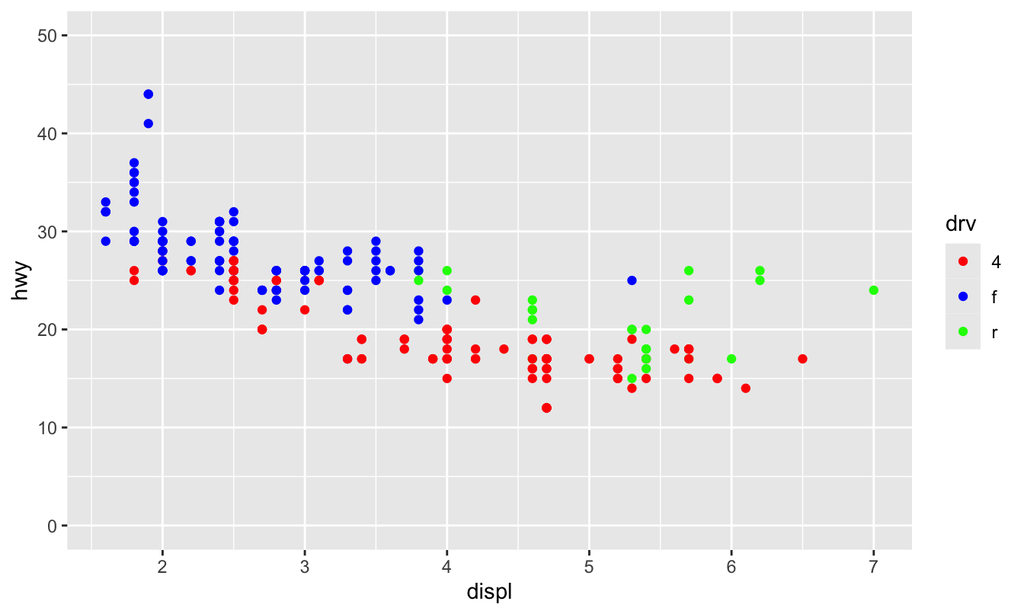

```r
ggplot(mpg, aes(x = displ, y = hwy, colour = drv)) +
  geom_point() +
  scale_colour_manual(values = c("red", "blue", "green")) +
  scale_y_continuous(limits = c(0, 50))
```

**Advertencia**

Ese ejercicio es de **sintaxis**, no de diseño. Rojo y verde juntos no se distinguen para una parte de cualquier grupo.

Una paleta de verdad se elige así:

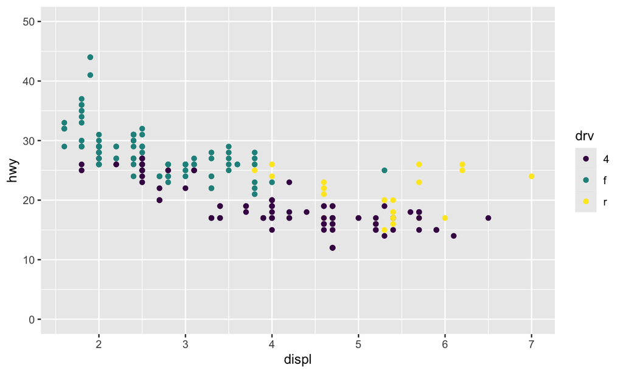

```r
ggplot(mpg, aes(x = displ, y = hwy, colour = drv)) +
  geom_point() +
  scale_colour_viridis_d() +
  scale_y_continuous(limits = c(0, 50))
```

## 7. Etiquetas y tema

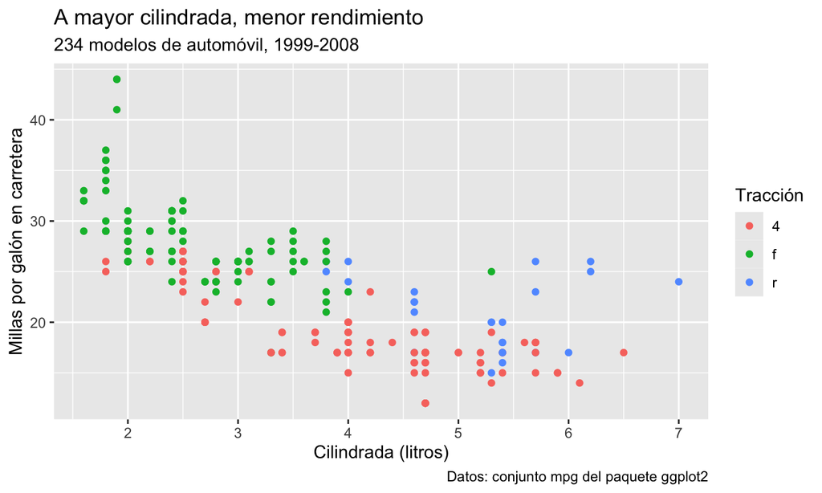

```r
ggplot(mpg, aes(x = displ, y = hwy, colour = drv)) +
  geom_point() +
  labs(
    title = "A mayor cilindrada, menor rendimiento",
    subtitle = "234 modelos de automóvil, 1999-2008",
    x = "Cilindrada (litros)",
    y = "Millas por galón en carretera",
    colour = "Tracción",
    caption = "Datos: conjunto mpg del paquete ggplot2"
  )
```

`displ` y `hwy` son nombres de columna, no etiquetas de eje. Una gráfica que sale de tu archivo de trabajo siempre lleva `labs()`.

### Temas

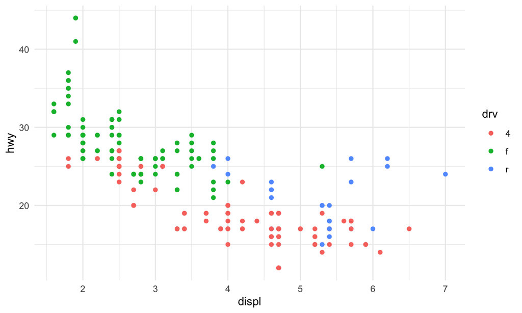

```r
base <- ggplot(mpg, aes(x = displ, y = hwy, colour = drv)) +
  geom_point()

base + theme_minimal()
```

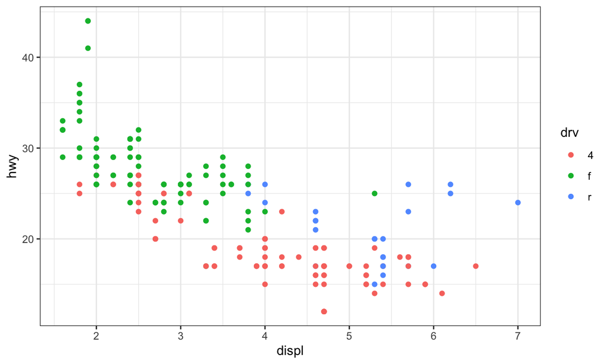

```r
base + theme_bw()
```

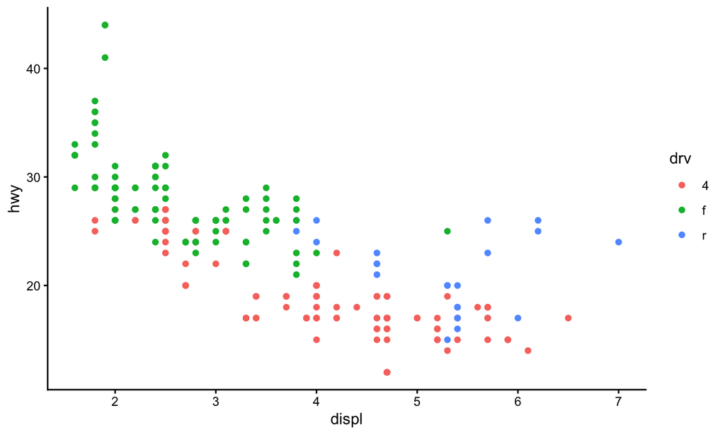

```r
base + theme_classic()
```

Fíjate en que **el tema no cambió los colores de los puntos**: eso son las escalas. El tema controla lo que no son datos.

Y fíjate también en que guardar la gráfica en `base` funcionó: en `ggplot2` una gráfica es un objeto de R, y por eso se le pueden sumar capas después.

## 8. La gráfica completa

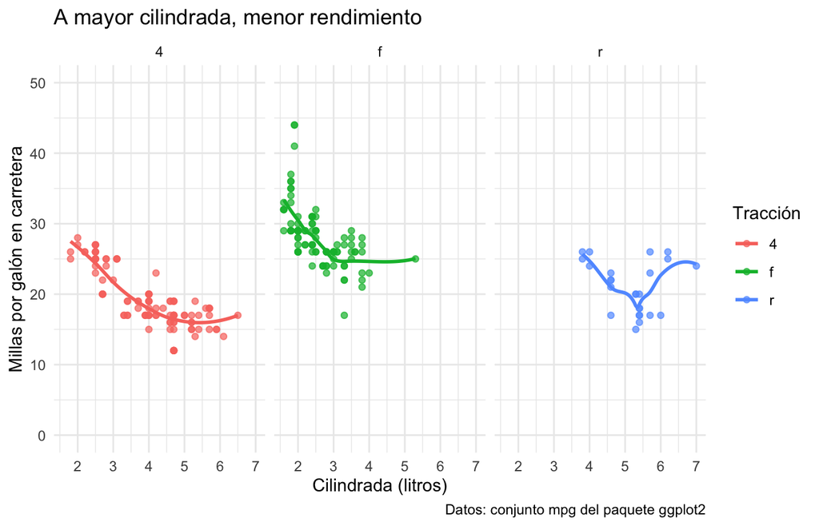

```r
ggplot(mpg, aes(x = displ, y = hwy, colour = drv)) + # data + aes
  geom_point(alpha = 0.7) + # geom
  geom_smooth(se = FALSE) + # geom + stat
  facet_wrap(~ drv) + # facet
  scale_y_continuous(limits = c(0, 50)) + # scale
  labs(
    title = "A mayor cilindrada, menor rendimiento",
    x = "Cilindrada (litros)",
    y = "Millas por galón en carretera",
    colour = "Tracción",
    caption = "Datos: conjunto mpg del paquete ggplot2"
  ) +
  theme_minimal() # theme
```

Cada línea es una de las ocho piezas de la gramática.

## 9. Guardar una gráfica

```r
grafica_final <- ggplot(mpg, aes(x = displ, y = hwy, colour = drv)) +
  geom_point() +
  theme_minimal()

ggsave("mi-grafica.png", grafica_final, width = 7, height = 4.5, dpi = 300)
```

`ggsave()` deduce el formato de la extensión: `.png`, `.pdf`, `.svg`. Los tres argumentos de tamaño importan más de lo que parece — una gráfica guardada con el tamaño por defecto suele salir con el texto desproporcionado.